# Data_Exploration_MarkDown

Kristen Higashi

08/07/2022

## Data Exploration Assignment

### Introduction

Just because people say “it’s not about the money” doesn’t mean that they don’t look at the return on investment when picking a college. The College Scorecard provides students a quick reference and ranking based on several factors. The main categories fall within: student demographics, race/gender/religious affiliations, post graduate opportunity, student retention, and of course the students’ average income post graduation.

This study seeks to determine if there is a correlation between release of the College Scorecard (first published in 2015)– specifically the release of graduates’ income – and student interest.

In this study, we use Google searches as a proxy to measure student interest. It is assumed that if a student read the college score card and were interested, they would Google the schools to learn more. Because the Google data set provides search information pre-2015, we were able to compare the interest searches before and after the release of the Scorecard.

To note, we do NOT have control over if the student read the scorecard before Googling or not, and therefore we will not be able to directly attribute the Google search to the College Scorecard. This is simply a baseline investigation before what will need to be a very deep dive into student perceived income importance.

### Findings

There is a clear correlation between income ratings in the College Scorecard and Google searches, however the impact is not large.

### Notes on Data

We also needed to consider student/school demographics (ie student ethnic demographics and affiliations. This also includes traditionally ‘all male’ and ‘all female’ schools, as well as Black, Asian, Native American, etc.). Historical affiliations are typically core to the college’s beliefs/priorities, thus it is rather rare for them to change over time.

While not included in this study, price of attening and long term student debt will also change accessibility to different schools. Lower income families typically do not have the funds or must take enormous loans to put a single student through school. In this instance, many students may not explore certain school opportunities if it is infeasible for them to pay for it.

#### Load Libraries

```r
library(car)
library(vtable)
library(jtools)
library(vtable)
library(purrr)
library(tidyverse)
library(dplyr)
library(lubridate)
library(fixest)
```

## Load/Join Data Tables

```r
score_card <- read.csv("Most+Recent+Cohorts+(Scorecard+Elements).csv")

# Bind "trends_up_to_" data
trends_all <- data.frame()
for (data in list.files(pattern = "trends_up_to_")){
  temp <- read.csv(data)
  trends_all <- rbind(trends_all, temp)
}

# Scorecard and ID CSVs
score_card <- read.csv("Most+Recent+Cohorts+(Scorecard+Elements).csv")
id_name <- read.csv("id_name_link.csv")%>%
  distinct(schname, .keep_all = TRUE)
coll_ids <- left_join(id_name, score_card, by = c("unitid"="UNITID"))
id_name <- read.csv("id_name_link.csv")
```

```r
# Full join - Removes all "not currently open institutions"
## College information
df_undg <-
  # Remove duplicate "schname" and join tables
  unique(left_join(trends_all, coll_ids, by = c("schname" = "schname")))%>%

  # filter for schools that predominantly grant bachelor degrees AND currently operating
  filter(PREDDEG == 3
         , !is.null(monthorweek)
         , CURROPER == 1)%>%
  # Flag for public v private
  mutate(is_pub = as.factor(CONTROL ==1)) %>%

  # categorize degrees

  # earnings
  mutate(num_earnings= as.numeric(md_earn_wne_p10.REPORTED.EARNINGS)) %>%
  filter(!is.na(num_earnings))%>%

  # Convert times
  mutate(month  = floor_date(ymd(str_sub(monthorweek, 0,10)), unit = c("month"))
         ,  yr = as.Date(str_sub(monthorweek, 1, 4), "%Y")) %>%
  mutate(pre_scorecard = as.factor(month < ymd("2015-01-01")))%>%
  mutate(key = paste(opeid,month, sep = "_"), date_state = paste(STABBR, monthorweek, sep="_"))%>%

  # Mutate variables to correct class(es)
  select(key, date_state, unitid, opeid, opeid6,    schname, INSTNM, STABBR, is_pub
         , month, yr, monthorweek, pre_scorecard
         , LOCALE
         , STABBR, num_earnings, keyword, keynum, index
         , c(HBCU:WOMENONLY), RELAFFIL, DISTANCEONLY
         , starts_with("PCIP")
         , starts_with("UGDS")
         , ACTCMMID, SAT_AVG, SAT_AVG_ALL, starts_with("NPT")
         , starts_with("RET")
         , starts_with("GRAD")
         , RPY_3YR_RT_SUPP, PCTFLOAN, PCTPELL, UG25abv, C150_4_POOLED_SUPP.REPORTED.GRAD.RATE, PPTUG_EF)%>%
  mutate_at(vars(c(HBCU:WOMENONLY), RELAFFIL, DISTANCEONLY), as.factor)%>%
  mutate_at(vars(matches("PCIP"), matches("UGDS")), as.numeric)%>%
  mutate_at(vars(matches("NPT"), matches("RET"), matches("GRAD"), RPY_3YR_RT_SUPP, PCTFLOAN, PCTPELL), as.numeric)%>%
  mutate(UG25abv = as.numeric(UG25abv), C150_4_POOLED_SUPP.REPORTED.GRAD.RATE= as.numeric( C150_4_POOLED_SUPP.REPORTED.GRAD.RATE), PPTUG_EF = as.numeric(PPTUG_EF))%>%
  mutate_at(vars(ACTCMMID, SAT_AVG, SAT_AVG_ALL), as.numeric)%>%

  # Determine count of searches and the max number of keywords searched
  group_by(schname, month)%>%
  mutate(ct_index = sum(index), num_keywords = max(keynum))%>%
  ungroup()%>%
  filter(!is.na(month), !is.na(num_earnings))%>%

  # Determine average, standard deviation, and avg+sd for each key word
  group_by(schname, month, keynum)%>%
  mutate(limit_index = mean(index) + sd(index))%>%
  ungroup()%>%

  # Determine if index is deemed above average (ie above avg+sd in state). TRUE/FALSE (True if larger than avg+stdev)
  mutate(exc_index = index >= limit_index)%>%
  filter(!is.na(exc_index)) %>%
  mutate(hi_lo_index = limit_index - index) %>%
  # Determine average, standard deviation, and avg+sd for earning (by state and date window since states will often have different average wages)
  group_by(date_state)%>%
  mutate(limit_earnings = mean(num_earnings) + sd(num_earnings))%>%
  ungroup()%>%

  # Determine if earnings are deemed above average (ie above avg+sd in state). TRUE/FALSE (True if larger than avg+stdev)
  mutate(exc_earning = num_earnings>= limit_earnings)%>%
  filter(!is.na(exc_earning))
```

[output not shown]

[output cut: 20 more lines]

[output not shown]

## Data Exploration

```r
summary(df_undg)
```

```
##      key             date_state            unitid           opeid
##  Length:916957      Length:916957      Min.   :100654   Min.   :  100200
##  Class :character   Class :character   1st Qu.:153126   1st Qu.:  197600
##  Mode  :character   Mode  :character   Median :190415   Median :  292700
##                                        Mean   :201228   Mean   : 1882382
##                                        3rd Qu.:220552   3rd Qu.:  371500
##                                        Max.   :475273   Max.   :72098867
##
##      opeid6        schname             INSTNM             STABBR
##  Min.   : 1002   Length:916957      Length:916957      Length:916957
##  1st Qu.: 1976   Class :character   Class :character   Class :character
##  Median : 2927   Mode  :character   Mode  :character   Mode  :character
##  Mean   : 4929
##  3rd Qu.: 3715
##  Max.   :40513
##
##    is_pub           month                  yr             monthorweek
##  FALSE:551837   Min.   :2013-03-01   Min.   :2013-08-08   Length:916957
##  TRUE :365120   1st Qu.:2013-12-01   1st Qu.:2013-08-08   Class :character
##                 Median :2014-09-01   Median :2014-08-08   Mode  :character
##                 Mean   :2014-09-12   Mean   :2014-11-03
##                 3rd Qu.:2015-06-01   3rd Qu.:2015-08-08
##                 Max.   :2016-03-01   Max.   :2016-08-08
##
##  pre_scorecard     LOCALE           num_earnings      keyword
##  FALSE:378506   Length:916957      Min.   : 16700   Length:916957
##  TRUE :538451   Class :character   1st Qu.: 36400   Class :character
##                 Mode  :character   Median : 41700   Mode  :character
##                                    Mean   : 43485
##                                    3rd Qu.: 48900
##                                    Max.   :166200
##
##      keynum          index       HBCU       PBI        ANNHI      TRIBAL
##  Min.   :1.000   Min.   :  0.0   0:876175   0:913998   0:914628   0:916333
##  1st Qu.:1.000   1st Qu.: 31.0   1: 40782   1:  2959   1:  2329   1:   624
##  Median :2.000   Median : 47.0
##  Mean   :2.835   Mean   : 47.9
##  3rd Qu.:4.000   3rd Qu.: 64.0
##  Max.   :9.000   Max.   :100.0
##
```

[output cut: 169 more lines]

```
##  Min.   :1.000   Min.   :  0.00   Mode :logical   Min.   :-45.7481
##  1st Qu.:3.000   1st Qu.: 41.12   FALSE:747734    1st Qu.:  0.8351
##  Median :5.000   Median : 57.59   TRUE :169223    Median :  5.3145
##  Mean   :4.635   Mean   : 56.42                   Mean   :  8.5268
##  3rd Qu.:6.000   3rd Qu.: 72.69                   3rd Qu.: 13.3528
##  Max.   :9.000   Max.   :116.78                   Max.   :114.7565
##
##  limit_earnings  exc_earning
##  Min.   :19836   Mode :logical
##  1st Qu.:48252   FALSE:788489
##  Median :52352   TRUE :128468
##  Mean   :53570
##  3rd Qu.:58867
##  Max.   :75373
##
```

```r
vtable(df_undg)
```

df_undg

| Name | Class | Values |
| --- | --- | --- |
| key | character |  |
| date_state | character |  |
| unitid | integer | Num: 100654 to 475273 |
| opeid | integer | Num: 100200 to 72098867 |
| opeid6 | integer | Num: 1002 to 40513 |
| schname | character |  |
| INSTNM | character |  |
| STABBR | character |  |
| is_pub | factor | ‘FALSE’ ‘TRUE’ |
| month | Date | Time: 2013-03-01 to 2016-03-01 |
| yr | Date | Time: 2013-08-08 to 2016-08-08 |
| monthorweek | character |  |
| pre_scorecard | factor | ‘FALSE’ ‘TRUE’ |
| LOCALE | character |  |
| num_earnings | numeric | Num: 16700 to 166200 |
| keyword | character |  |
| keynum | integer | Num: 1 to 9 |
| index | integer | Num: 0 to 100 |
| HBCU | factor | ‘0’ ‘1’ |
| PBI | factor | ‘0’ ‘1’ |
| ANNHI | factor | ‘0’ ‘1’ |
| TRIBAL | factor | ‘0’ ‘1’ |
| AANAPII | factor | ‘0’ ‘1’ |
| HSI | factor | ‘0’ ‘1’ |
| NANTI | factor | ‘0’ ‘1’ |
| MENONLY | factor | ‘0’ ‘1’ |
| WOMENONLY | factor | ‘0’ ‘1’ |
| RELAFFIL | factor | ‘100’ ‘102’ ‘103’ ‘22’ ‘24’ and more |
| DISTANCEONLY | factor | ‘0’ ‘1’ |
| PCIP01 | numeric | Num: 0 to 0.39 |

[output cut: 81 more lines]

```r
pre_post <- feols(exc_index~pre_scorecard, data = df_undg)
pre_post
```

```
## OLS estimation, Dep. Var.: exc_index
## Observations: 916,957
## Standard-errors: IID
##                    Estimate Std. Error  t value  Pr(>|t|)
## (Intercept)        0.190673   0.000630 302.4194 < 2.2e-16 ***
## pre_scorecardTRUE -0.010430   0.000823 -12.6771 < 2.2e-16 ***
## ---
## Signif. codes:  0 '***' 0.001 '**' 0.01 '*' 0.05 '.' 0.1 ' ' 1
## RMSE: 0.387897   Adj. R2: 1.741e-4
```

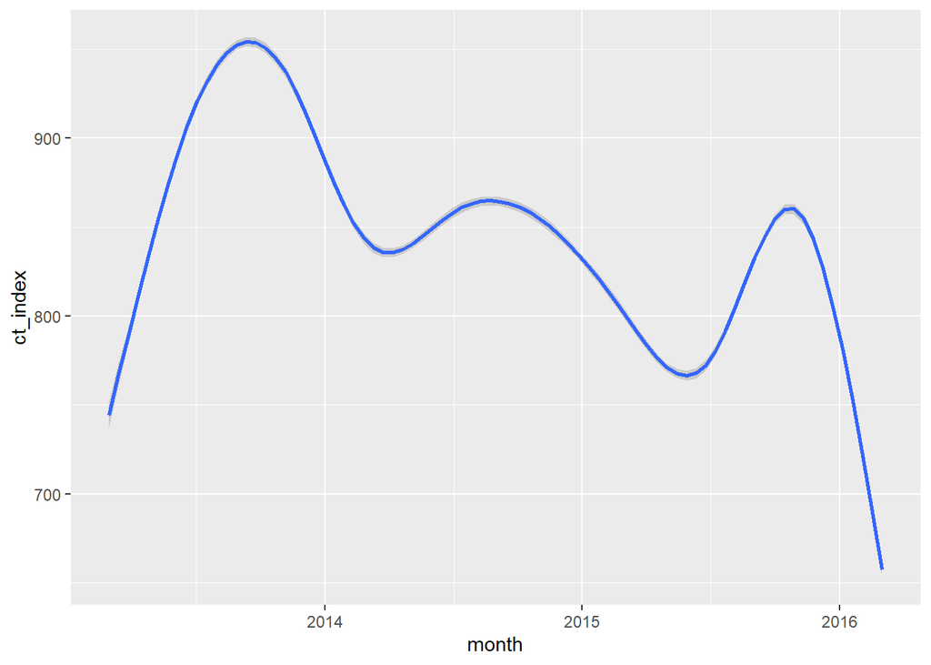

```r
ggplot(df_undg, aes(x = month, y = ct_index)) + geom_smooth()
```

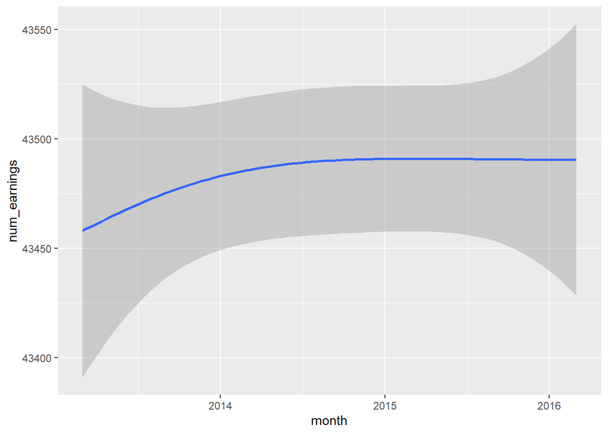

```r
ggplot(df_undg, aes(x = month, y = num_earnings)) + geom_smooth()
```

```r
pre_and_earnings <- feols(exc_index~pre_scorecard +num_earnings, data = df_undg)
pre_and_earnings
```

```
## OLS estimation, Dep. Var.: exc_index
## Observations: 916,957
## Standard-errors: IID
##                       Estimate   Std. Error  t value  Pr(>|t|)
## (Intercept)        0.206500560 0.0016350703 126.2946 < 2.2e-16 ***
## pre_scorecardTRUE -0.010433027 0.0008227273 -12.6810 < 2.2e-16 ***
## num_earnings      -0.000000364 0.0000000347 -10.4911 < 2.2e-16 ***
## ---
## Signif. codes:  0 '***' 0.001 '**' 0.01 '*' 0.05 '.' 0.1 ' ' 1
## RMSE: 0.387874   Adj. R2: 2.93e-4
```

```r
earn <- feols(ct_index~num_earnings, data = df_undg)
pre_score <- feols(ct_index~pre_scorecard, data = df_undg)
etable(pre_and_earnings, earn, pre_score)
```

```
##                        pre_and_earnings                earn         pre_score
## Dependent Var.:               exc_index            ct_index          ct_index
##
## (Intercept)          0.2065*** (0.0016)    550.7*** (1.782) 797.3*** (0.7278)
## pre_scorecardTRUE   -0.0104*** (0.0008)                     77.91*** (0.9498)
## num_earnings      -3.64e-7*** (3.47e-8) 0.0067*** (3.96e-5)
## _________________ _____________________ ___________________ _________________
## S.E. type                           IID                 IID               IID
## Observations                    916,957             916,957           916,957
## R2                              0.00030             0.03051           0.00728
## Adj. R2                         0.00029             0.03051           0.00728
## ---
## Signif. codes: 0 '***' 0.001 '**' 0.01 '*' 0.05 '.' 0.1 ' ' 1
```

```r
demog <- feols(hi_lo_index~num_earnings + HBCU +PBI+ PBI+ ANNHI+ TRIBAL+ AANAPII+ HSI+ NANTI+ MENONLY+ WOMENONLY
      , data = df_undg)
demog
```

```
## OLS estimation, Dep. Var.: hi_lo_index
## Observations: 916,957
## Standard-errors: IID
##               Estimate Std. Error    t value   Pr(>|t|)
## (Intercept)   9.598332 0.04781684 200.731213  < 2.2e-16 ***
## num_earnings -0.000025 0.00000104 -24.257470  < 2.2e-16 ***
## HBCU1        -0.189612 0.05880728  -3.224288 1.2629e-03 **
## PBI1         -1.605816 0.20791683  -7.723359 1.1342e-14 ***
## ANNHI1        1.053668 0.23490094   4.485586 7.2722e-06 ***
## TRIBAL1       2.562515 0.45198019   5.669530 1.4323e-08 ***
## AANAPII1     -0.038955 0.16352254  -0.238226 8.1171e-01
## HSI1          0.771911 0.07274380  10.611364  < 2.2e-16 ***
## ... 3 coefficients remaining (display them with summary() or use argument n)
## ---
## Signif. codes:  0 '***' 0.001 '**' 0.01 '*' 0.05 '.' 0.1 ' ' 1
## RMSE: 11.3   Adj. R2: 0.00102
```

```r
etable(demog)
```

```
##                                 demog
## Dependent Var.:           hi_lo_index
##
## (Intercept)         9.598*** (0.0478)
## num_earnings    -2.53e-5*** (1.04e-6)
## HBCU1              -0.1896** (0.0588)
## PBI1               -1.606*** (0.2079)
## ANNHI1              1.054*** (0.2349)
## TRIBAL1             2.563*** (0.4520)
## AANAPII1             -0.0390 (0.1635)
## HSI1               0.7719*** (0.0727)
## NANTI1               0.3686. (0.1889)
## MENONLY1              0.1990 (0.2614)
## WOMENONLY1         0.7084*** (0.0830)
## _______________ _____________________
## S.E. type                         IID
## Observations                  916,957
## R2                            0.00103
## Adj. R2                       0.00102
## ---
## Signif. codes: 0 '***' 0.001 '**' 0.01 '*' 0.05 '.' 0.1 ' ' 1
```

## Regression

```r
deg_types <- df_undg %>%
  mutate(hi_lo_index = limit_index - index) %>%
  mutate(land_degs = PCIP01 + PCIP03 + PCIP30 + PCIP31 + PCIP48 + PCIP49
    , stem_degs = PCIP04 + PCIP11 + PCIP14 + PCIP15 + PCIP19 + PCIP26 + PCIP27 + PCIP29 + PCIP40 +
      PCIP41 + PCIP51

    , social_science_degs = PCIP05 + PCIP22 + PCIP38 + PCIP39 + PCIP42 + PCIP45 + PCIP52 + PCIP54

    , lit_degs = PCIP09 + PCIP10 + PCIP16 + PCIP23 + PCIP24 + PCIP25 + PCIP50

    , phys_trades_deg = PCIP12 + PCIP46 + PCIP47

    , pub_trades_deg = PCIP13 + PCIP43 + PCIP44

    , all_test = PCIP01 + PCIP03 + PCIP30 + PCIP31 + PCIP48 + PCIP49 + PCIP04 + PCIP11 + PCIP14 +
      PCIP15 + PCIP19 + PCIP26 + PCIP27 + PCIP29 + PCIP40 + PCIP41 + PCIP51 + PCIP05 + PCIP22 +
      PCIP38 + PCIP39 + PCIP42 + PCIP45 + PCIP52 + PCIP54 + PCIP09 + PCIP10 + PCIP16 + PCIP23 +
      PCIP24 + PCIP25 + PCIP50 + PCIP12 + PCIP46 + PCIP47 + PCIP13 + PCIP43 + PCIP44
  ) %>%

  select (
    month, num_earnings, index, limit_index, all_test,land_degs, stem_degs, social_science_degs, lit_degs
          , phys_trades_deg, pub_trades_deg, LOCALE
          , pre_scorecard, exc_index, ct_index, hi_lo_index
          ,  num_earnings, limit_earnings,exc_earning, num_earnings, is_pub
          , HBCU, PBI, PBI, ANNHI, TRIBAL, AANAPII, HSI, NANTI, MENONLY, WOMENONLY
          , PCIP01, PCIP03, PCIP30, PCIP31, PCIP48, PCIP49, PCIP04, PCIP11, PCIP14
          , PCIP15, PCIP19, PCIP26, PCIP27, PCIP29, PCIP40, PCIP41, PCIP51, PCIP05
          , PCIP22, PCIP38, PCIP39, PCIP42, PCIP45, PCIP52, PCIP54, PCIP09, PCIP10
          , PCIP16, PCIP23, PCIP24, PCIP25, PCIP50, PCIP12, PCIP46, PCIP47, PCIP13
          , PCIP43, PCIP44
)

### WONT KNIT UNLESS I COMMENT OUT.... MAYBE A SIGN I DID THIS WRONG =(

# lm(hi_lo_index )
# summary(deg_types)deg_types
deg_type_check <- feols(ct_index~num_earnings + pre_scorecard |
      # College Affiliations
      HBCU +PBI+PBI+ ANNHI + TRIBAL+ AANAPII+HSI+NANTI
      # % Of Degrees by type
      # + PCIP01 + PCIP03 + PCIP30 + PCIP31 + PCIP48 + PCIP49 + PCIP04 + PCIP11 + PCIP14
      # + PCIP15 + PCIP19 + PCIP26 + PCIP27 + PCIP29 + PCIP40 + PCIP41 + PCIP51 + PCIP05
      # + PCIP22 + PCIP38 + PCIP39 + PCIP42 + PCIP45 + PCIP52 + PCIP54 + PCIP09 + PCIP10
      # + PCIP16 + PCIP23 + PCIP24 + PCIP25 + PCIP50 + PCIP12 + PCIP46 + PCIP47 + PCIP13
      # + PCIP43 + PCIP44
      # loaction of school
      + LOCALE
  , data = deg_types)

etable(deg_type_check)
```

```
##                     deg_type_check
## Dependent Var.:           ct_index
##
## num_earnings      0.0059* (0.0001)
## pre_scorecardTRUE   77.92* (3.650)
## Fixed-Effects:    ----------------
## HBCU                           Yes
## PBI                            Yes
## ANNHI                          Yes
## TRIBAL                         Yes
## AANAPII                        Yes
## HSI                            Yes
## NANTI                          Yes
## LOCALE                         Yes
## _________________ ________________
## S.E.: Clustered           by: HBCU
## Observations               916,957
## R2                         0.06369
## Within R2                  0.02882
## ---
## Signif. codes: 0 '***' 0.001 '**' 0.01 '*' 0.05 '.' 0.1 ' ' 1
```

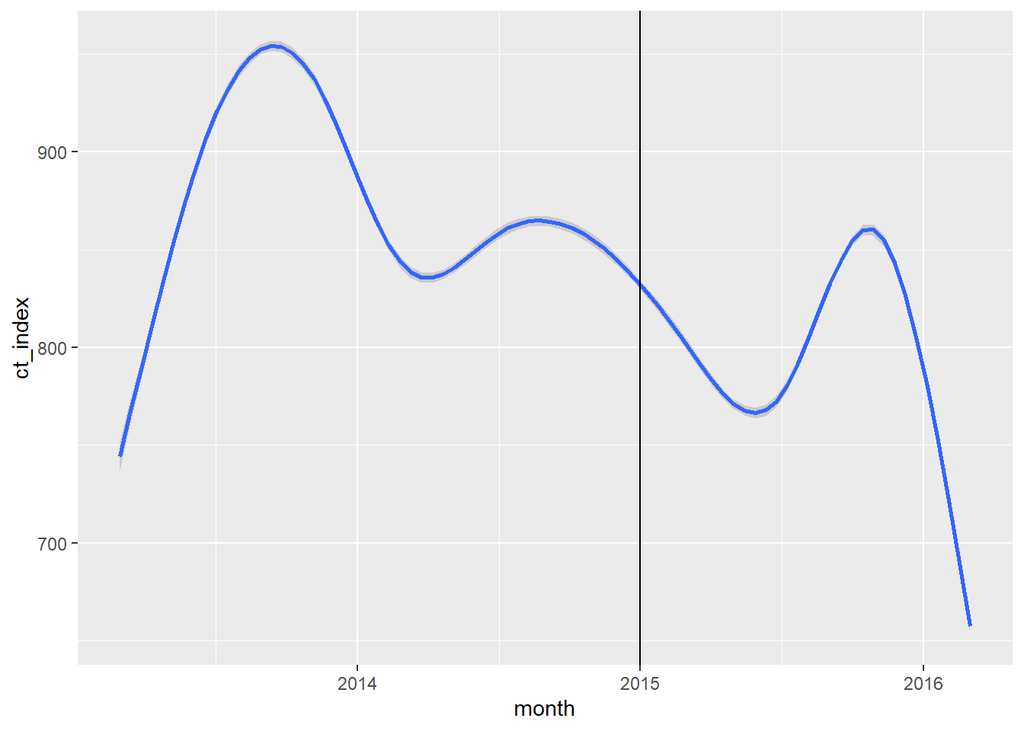

```r
deg_types %>%  group_by(month) %>% mutate(avg_hi_lo = mean(hi_lo_index)) %>%
  ggplot(aes(x= month, y = ct_index)) + geom_smooth()+
  geom_vline(xintercept = floor_date(ymd(str_sub("2015-01-01", 0,10)), unit = c("month")))
```

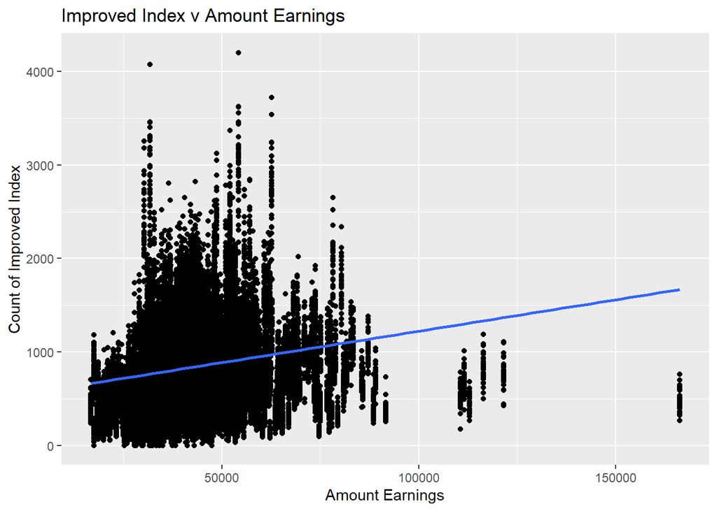

```r
deg_types %>%  group_by(month) %>% mutate(avg_hi_lo = mean(hi_lo_index)) %>%
  ggplot(aes(x= num_earnings, y = ct_index)) +  geom_point()+ geom_smooth(method = 'lm') + labs(x = "Amount Earnings", y = "Count of Improved Index", title = "Improved Index v Amount Earnings")
```

```r
# ggplot(deg_types, aes(x = num_earnings, y = ct_index))+ geom_point() geom_smooth(method = 'lm')
```